# Featured Recipe #3: Creating a route planner for road network

> This is a featured recipe from the [**IPython Cookbook**](http://ipython-books.github.io/), the definitive guide to **high-performance scientific computing** and **data science** in Python.

In this featured recipe, we create a simple **GPS-like route planner** in Python. We retrieve California's road network data from the *United States Census Bureau* in order to find shortest paths and compute road itineraries between any two locations in California.

## Getting Ready

For this recipe, you need IPython, NumPy, Pandas, matplotlib.

You also need [NetworkX](http://networkx.github.io/) and [GDAL/OGR](http://www.gdal.org/ogr/). On Windows, you can find binary installers on [Chris Gohlke's webpage](http://www.lfd.uci.edu/~gohlke/pythonlibs/).

> At the time of this writing, NetworkX's support of Shapefile doesn't seem to be compatible with Python 3.x. For this reason, this recipe has only been successfully tested with Python 2.x.

You also need [**Smopy**](https://github.com/rossant/smopy) and [Pillow](https://pillow.readthedocs.org/en/latest/) for displaying [OpenStreetMap maps](http://www.openstreetmap.org/):

```python
!pip install smopy
```

Finally, you need to download the [*Road* dataset](https://github.com/ipython-books/cookbook-data) on the book's website an extract it in the current folder. The data comes from the [United States Census Bureau website](http://www.census.gov/geo/maps-data/data/tiger.html).

## How to do it...

1. Let's import the packages.

```python
import networkx as nx
import numpy as np
import pandas as pd
import json
import smopy
import matplotlib.pyplot as plt
%matplotlib inline
import matplotlib as mpl
mpl.rcParams['figure.dpi'] = mpl.rcParams['savefig.dpi'] = 300
```

```
Couldn't import dot_parser, loading of dot files will not be possible.
```

2. We load the data (a Shapefile dataset) with NetworkX. This dataset contains detailed information about the primary roads in California. NetworkX's `read_shp` function returns a graph, where each node is a geographical position, and each edge contains information about the road linking the two nodes.

```python
g = nx.read_shp("data/tl_2013_06_prisecroads.shp")
```

3. This graph is not necessarily connected, but we need a connected graph in order to compute shortest paths. Here, we take the largest connected subgraph using the `connected_component_subgraphs` function.

```python
sg = list(nx.connected_component_subgraphs(g.to_undirected()))[0]
len(sg)
```

```
464
```

4. We define two positions (with the latitude and longitude). We will find the shortest path between these two positions.

```python
pos0 = (36.6026, -121.9026)
pos1 = (34.0569, -118.2427)
```

5. Each edge in the graph contains information about the road, including a list of points along this road. We first create a function that returns this array of coordinates, for any edge in the graph.

```python
def get_path(n0, n1):
    """If n0 and n1 are connected nodes in the graph, this function
    return an array of point coordinates along the road linking
    these two nodes."""
    return np.array(json.loads(sg[n0][n1]['Json'])['coordinates'])
```

6. We will notably use the road path to compute its length. We first need to define a function that computes the distance between any two points in geographical coordinates. This function has been found in [StackOverflow](http://stackoverflow.com/questions/8858838/need-help-calculating-geographical-distance).

```python
EARTH_R = 6372.8
def geocalc(lat0, lon0, lat1, lon1):
    """Return the distance (in km) between two points in
    geographical coordinates."""
    lat0 = np.radians(lat0)
    lon0 = np.radians(lon0)
    lat1 = np.radians(lat1)
    lon1 = np.radians(lon1)
    dlon = lon0 - lon1
    y = np.sqrt(
        (np.cos(lat1) * np.sin(dlon)) ** 2
         + (np.cos(lat0) * np.sin(lat1)
         - np.sin(lat0) * np.cos(lat1) * np.cos(dlon)) ** 2)
    x = np.sin(lat0) * np.sin(lat1) + \
        np.cos(lat0) * np.cos(lat1) * np.cos(dlon)
    c = np.arctan2(y, x)
    return EARTH_R * c
```

7. Now, we define a function computing a path's length.

```python
def get_path_length(path):
    return np.sum(geocalc(path[1:,0], path[1:,1],
                          path[:-1,0], path[:-1,1]))
```

8. Now, we update our graph by computing the distance between any two connected nodes. We add this information in the `distance` attribute of the edges.

```python
# Compute the length of the road segments.
for n0, n1 in sg.edges_iter():
    path = get_path(n0, n1)
    distance = get_path_length(path)
    sg.edge[n0][n1]['distance'] = distance
```

9. The last step before we can find the shortest path in the graph, is to find the two nodes in the graph that are closest to the two requested positions.

```python
nodes = np.array(sg.nodes())
# Get the closest nodes in the graph.
pos0_i = np.argmin(np.sum((nodes[:,::-1] - pos0)**2, axis=1))
pos1_i = np.argmin(np.sum((nodes[:,::-1] - pos1)**2, axis=1))
```

10. Now, we use NetworkX's `shortest_path` function to compute the shortest path between our two positions. We specify that the weight of every edge is the length of the road between them.

```python
# Compute the shortest path.
path = nx.shortest_path(sg,
                        source=tuple(nodes[pos0_i]),
                        target=tuple(nodes[pos1_i]),
                        weight='distance')
len(path)
```

```
19
```

11. The itinerary has been computed. The `path` variable contains the list of edges that form the shortest path between our two positions. Now, we can get information about the itinerary with Pandas. The dataset has a few fields of interest, including the name and type (State, Interstate, etc.) of the roads.

```python
roads = pd.DataFrame([sg.edge[path[i]][path[i + 1]]
                      for i in range(len(path) - 1)],
                     columns=['FULLNAME', 'MTFCC',
                              'RTTYP', 'distance'])
roads
```

|  | FULLNAME | MTFCC | RTTYP | distance |
| --- | --- | --- | --- | --- |
| 0 | State Rte 1 | S1200 | S | 100.658130 |
| 1 | State Rte 1 | S1200 | S | 33.419556 |
| 2 | Cabrillo Hwy | S1200 | M | 4.399051 |
| 3 | State Rte 1 | S1200 | S | 12.400382 |
| 4 | Cabrillo Hwy | S1200 | M | 36.693272 |
| 5 | Cabrillo Hwy | S1200 | M | 0.017746 |
| 6 | Cabrillo Hwy | S1200 | M | 0.439355 |
| 7 | Cabrillo Hwy | S1200 | M | 0.130107 |
| 8 | State Hwy 1 | S1200 | S | 0.007007 |
| 9 | el Camino Real | S1200 | M | 5.774056 |
| 10 | el Camino Real | S1200 | M | 0.507131 |
| 11 | el Camino Real | S1200 | M | 33.550742 |
| 12 | US Hwy 101 | S1200 | U | 140.786519 |
| 13 | US Hwy 101 | S1200 | U | 75.852281 |
| 14 | Ventura Fwy | S1200 | M | 49.045475 |
| 15 | Hollywood Fwy | S1200 | M | 0.885826 |
| 16 | Hollywood Fwy | S1200 | M | 14.087603 |
| 17 | Hollywood Fwy | S1200 | M | 0.010107 |

Here is the total length of this itinerary.

```python
roads['distance'].sum()
```

```
508.66434555909808
```

12. Finally, let display the itinerary on the map. We first retrieve the map with Smopy.

```python
map = smopy.Map(pos0, pos1, z=7, margin=.1)
```

13. Our path contains connected nodes in the graph. Every edge between two nodes is characterized by a list of points (constituting a part of the road). Therefore, we need to define a function that concatenates the positions along every edge in the path. A difficulty is that we need to concatenate the positions in the right order along our path. We choose the order based on the fact that the last point in an edge needs to be close to the first point in the next edge.

```python
def get_full_path(path):
    """Return the positions along a path."""
    p_list = []
    curp = None
    for i in range(len(path)-1):
        p = get_path(path[i], path[i+1])
        if curp is None:
            curp = p
        if np.sum((p[0]-curp)**2) > np.sum((p[-1]-curp)**2):
            p = p[::-1,:]
        p_list.append(p)
        curp = p[-1]
    return np.vstack(p_list)
```

14. We convert the path in pixels in order to display it on the Smopy map.

```python
linepath = get_full_path(path)
x, y = map.to_pixels(linepath[:,1], linepath[:,0])
```

15. Finally, we display the map, with our two positions and the computed itinerary between them.

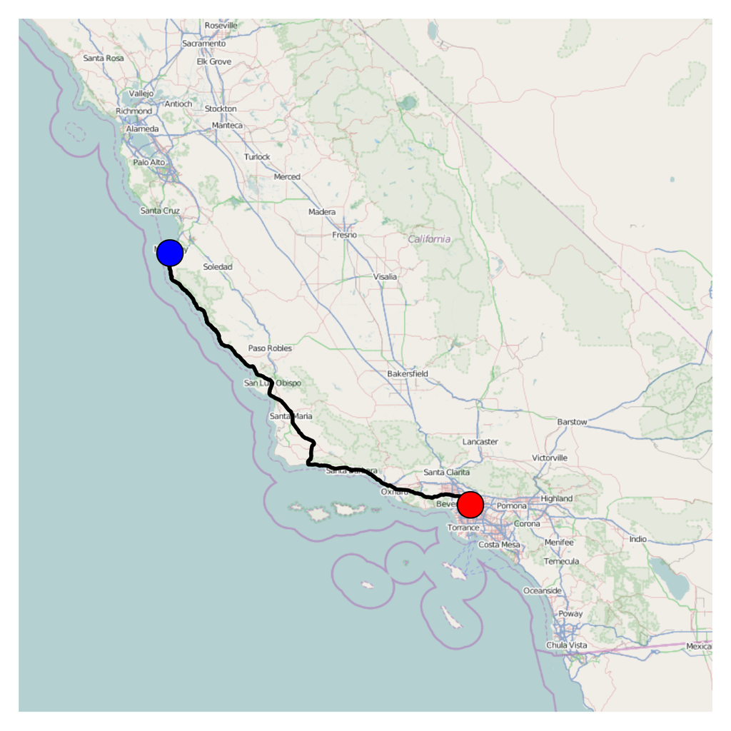

```python
plt.figure(figsize=(6,6));
map.show_mpl();
# Plot the itinerary.
plt.plot(x, y, '-k', lw=1.5);
# Mark our two positions.
plt.plot(x[0], y[0], 'ob', ms=10);
plt.plot(x[-1], y[-1], 'or', ms=10);
```

## How it works...

We computed the shortest path with NetworkX's `shortest_path` function. Here, this function used **Dijkstra's algorithm**. This algorithm has a wide variety of applications, for example in network routing protocols.

There are different ways to compute the geographical distance between two points. Here, we used a relatively precise formula: the **orthodromic distance** (also called **great-circle distance**), which assumes that the Earth is a perfect sphere. We could also have used a simpler formula since the distance between two successive points on a road is small.

## There's more...

You can find more information about shortest path problems and Dijkstra's algorithm in the following references:

- [Shortest path](http://en.wikipedia.org/wiki/Shortest_path_problem).
- [Dijkstra's algorithm](http://en.wikipedia.org/wiki/Dijkstra%27s_algorithm).

Here are a few references about geographical distances:

- [Geographical distance](http://en.wikipedia.org/wiki/Geographical_distance).
- [Great circle](http://en.wikipedia.org/wiki/Great_Circle).
- [Great circle distance](http://en.wikipedia.org/wiki/Great-circle_distance).

> This was a featured recipe from the [IPython Cookbook](http://ipython-books.github.io/), by [Cyrille Rossant](http://cyrille.rossant.net), Packt Publishing, 2014. If you liked this recipe, [pre-order the book now](http://www.packtpub.com/ipython-interactive-computing-and-visualization-cookbook/book)! There's a time-limited 50% discount with the code `PICVCEB`.